# Introduction to clonealign

Kieran R Campbell

Department of Statistics, University of British Columbia  
Department of Molecular Oncology, BC Cancer Agency  
UBC Data Science Institute, University of British Columbia

kicampbell@bccrc.ca

September 2019

#### Package

clonealign 1.99.2

# 1 Overview

`clonealign` assigns cells measured using single-cell RNA-seq to their clones of origin using copy number data. This is especially useful when clones are inferred from shallow single-cell DNA-seq, in which case the copy number state of each clone is known, but the precise SNV structure is unknown.

To assign cells to clones, `clonealign` makes the assumption that

$$\text{gene expression} \propto \text{number of gene copies}$$

This is demonstrated in the figure below.

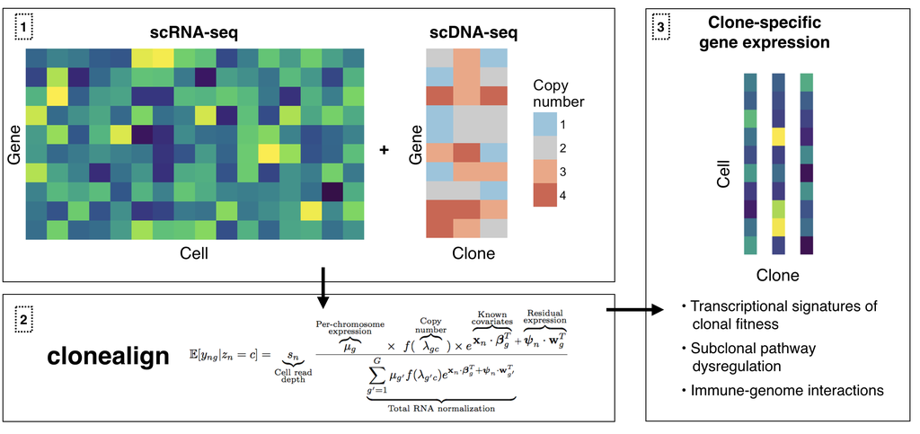

$$z_n = c \text{ if cell $n$ on clone $c$}$$

where $s_n$ is a cell-specific size factor, $\mu_g$ is the per-chromosome expression (normalized so that $\mu_1 = 1$ for model identifiability), $f$ is a function that maps copy number to a multiplicative factor of expression, and $\psi$ and $w$ are cell and gene specific random effects. As of clonealign 2.0, the noise distribution is assumed to be multinomial. Inference is performed using reparametrization-gradient variational inference to calculate a posterior distribution of the clone assignments $z_n$ and of all other model parameters.

# 2 Installation

`clonealign` is built upon [Google’s Tensorflow](https://www.tensorflow.org/) using the [Tensorflow R package provided by Rstudio](https://tensorflow.rstudio.com/). To install `tensorflow`, run

```r
install.packages("tensorflow")
tensorflow::install_tensorflow(extra_packages ="tensorflow-probability", version="1.13.1")
```

You can confirm the installation succeeded by running

```r
sess = tf$Session()
hello <- tf$constant('Hello, TensorFlow!')
sess$run(hello)
```

For more details see the [Rstudio page on tensorflow installation](https://tensorflow.rstudio.com/tensorflow/articles/installation.html).

`clonealign` can then be installed using the `devtools` package via

```r
devtools::install_github("kieranrcampbell/clonealign")
```

# 3 Basic usage

## 3.1 Data preparation

By default, `clonealign` requires two inputs:

- Gene expression data as raw counts. This can be in the form of a `SingleCellExperiment`, `SummarizedExperiment` or **cell by gene** `matrix`
- Copy number profiles for each clone and gene (where the genes **must** be the same as those measured in the expression data). This can be in the form of a `data.frame`, `DataFrame` or `matrix`

Bundled with the package is an example `SingleCellExperiment` for 100 genes and 200 cells:

```r
library(clonealign)
data(example_sce)
example_sce
```

```
#> class: SingleCellExperiment
#> dim: 100 200
#> metadata(0):
#> assays(1): counts
#> rownames(100): gene_1 gene_2 ... gene_99 gene_100
#> rowData names(3): A B C
#> colnames(200): cell_1 cell_2 ... cell_199 cell_200
#> colData names(0):
#> reducedDimNames(0):
#> spikeNames(0):
```

This has raw integer counts in the `assays` slot as required for input to `clonealign`:

```r
assay(example_sce, "counts")[1:5, 1:5]
```

```
#>        cell_1 cell_2 cell_3 cell_4 cell_5
#> gene_1      0      0      0      0      0
#> gene_2      0      0      0      0      0
#> gene_3      1      1      1      0      0
#> gene_4      0      0      0      0      0
#> gene_5      1      0      0      1      0
```

The CNV data is stored in the `rowData` of the `SingleCellExperiment` for 3 clones (A, B, and C) and crucially the same genes as the expression data:

```r
cnv_data <- rowData(example_sce)[, c("A", "B", "C")]
stopifnot(nrow(cnv_data) == nrow(example_sce)) # Make sure genes match up
head(cnv_data)
```

```
#> DataFrame with 6 rows and 3 columns
#>                A         B         C
#>        <integer> <integer> <integer>
#> gene_1         1         2         2
#> gene_2         2         1         1
#> gene_3         3         2         2
#> gene_4         3         2         2
#> gene_5         2         2         3
#> gene_6         2         1         1
```

We next run the `preprocess_for_clonealign` that performs the following filtering steps:

- Removes genes with fewer than `min_counts_per_gene` counts mapped
- Removes cells with fewer than `min_counts_per_cell` counts mapped
- If `remove_outlying_genes` is `TRUE`, removes genes whose mean expression is more than `nmads` MADs away from the overall mean
- Removes genes whose maximum copy number is greater than `max_copy_number`
- If `remove_genes_same_copy_number` is `TRUE`, removes genes whose copy number is the same across all clones

Note that it is critical before running clonealign that **genes on the sex chromosomes are removed**, as these violate the gene dosage assumption due to e.g. X inactivation. To get a list of genes and their respective chromosomes, we suggest using the annotables package.

```r
ca_data <- preprocess_for_clonealign(example_sce, cnv_data)
```

## 3.2 Model fitting

The model is fitted with a basic call to `run_clonealign`, which calls the `clonealign` function across a range of parameter initializations and picks the model fit that achieves the best ELBO.

```r
cal <- run_clonealign(ca_data$gene_expression_data, ca_data$copy_number_data, seed = 123)
```

[output not shown]

[output cut: 9 more lines]

```
#> Constructing tensorflow graph
#> Set session seed to 648795 (disabled GPU)
#> Removing 1 genes with low counts
#> Optimizing ELBO
#>
#> ELBO converged or reached max iterations
#> Computing final ELBO
#> Constructing tensorflow graph
#> Set session seed to 985797 (disabled GPU)
#> Removing 1 genes with low counts
#> Optimizing ELBO
#>
#> ELBO converged or reached max iterations
#> Computing final ELBO
#> ELBOs:  -562.642123413086 -562.63835144043 -562.625122070312 -562.864599609375 -562.871282958984 -562.859097290039 -562.870913696289 -562.893487548828 -562.904473876953
```

Note we have set a random seed, which in turn will set seeds for each of the runs to ensure reproducibility.

```r
print(cal)
```

```
#> A clonealign_fit for 6 cells, 66 genes, and 3 clones
#> To access clone assignments, call x$clone
#> To access ML parameter estimates, call x$ml_params
```

We can plot the ELBO to ensure convergence:

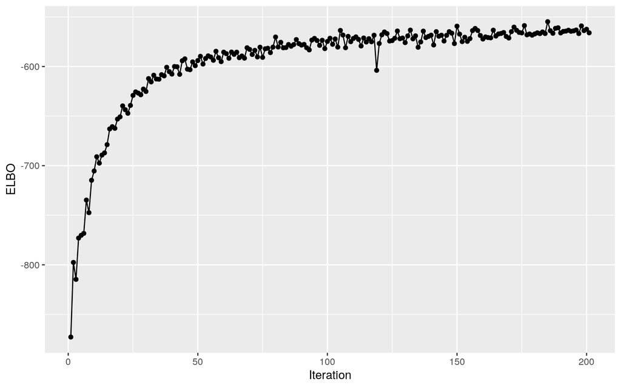

```r
qplot(seq_along(cal$convergence_info$elbo), cal$convergence_info$elbo, geom = c("point", "line")) +
  labs(x = "Iteration", y = "ELBO")
```

The maximum likelihood estimates of the clone assignments can be access through the `clone` slot:

```r
clones <- cal$clone
table(clones)
```

```
#> clones
#> A
#> 6
```

and we can make a heatmap of the clonal assignment probabilities:

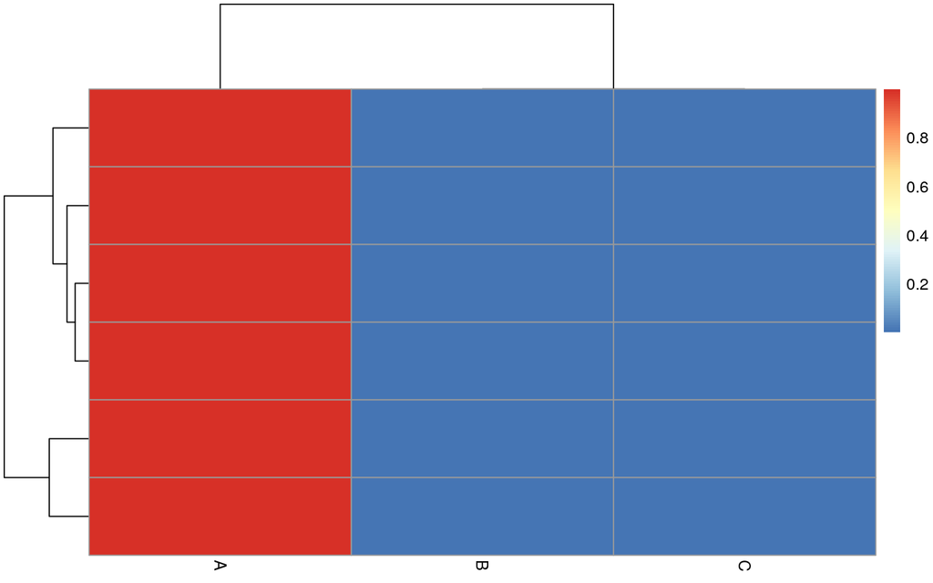

```r
pheatmap::pheatmap(cal$ml_params$clone_probs)
```

This can easily be added to the `SingleCellExperiment` for visualization with `scater`, after subsetting to the retained cells from the `preprocess_for_clonealign` call

```r
example_sce <- example_sce[, ca_data$retained_cells]
example_sce$clone <- clones
example_sce <- normalize(example_sce)
```

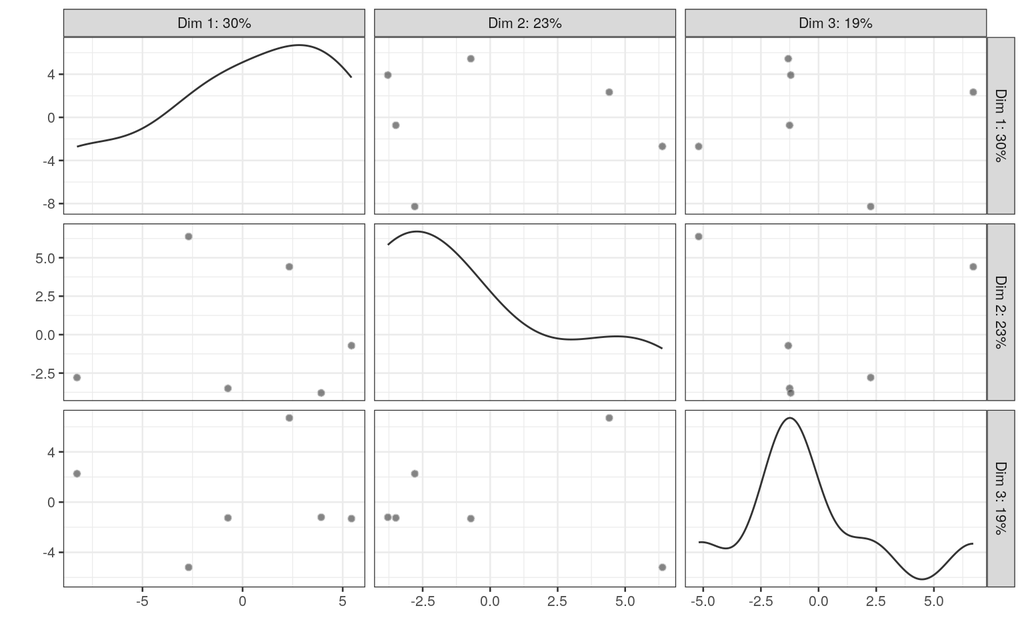

```r
plotPCA(example_sce, ncomponents = 3, colour_by = "clone")
```

The clone assignments in `clones` can then be used for the desired downstream analysis, such as differential expression or SNV analysis.